## Classifying Exercise Performance Quality from Weightlifting Exercise Data

### Overview

This analysis is based on data collected from the study, “Qualitative Activity Recognition of Weight Lifting Exercises,” by Vellaso, Bulling, Gellersem, Ugulino, adn Fuks. During this study, data was collected from sensors while subjects performed weightlifting exercises. Instead of trying to determine which exercises were performed, the team proposed that a model could be created to assess and categorize the quality of the exercise performance. In this analysis, a predictive model will be created from the same data and an attempt will be made to accurately categorize or match the classes assigned to the data during the study.

### Obtain Project Training and Testing Data Sets

Below the training and testing data sets for this project are downloaded from the sites provided, saved to the working directory, and then read into trainSet and testSet dataframes.

```r
fileURLtrain <- "http://d396qusza40orc.cloudfront.net/predmachlearn/pml-training.csv"
download.file(fileURLtrain,mode="wb",destfile="./pml-training.csv")

fileURLtest <- "http://d396qusza40orc.cloudfront.net/predmachlearn/pml-testing.csv"
download.file(fileURLtest,mode="wb",destfile="./pml-testing.csv")

trainSet<-read.csv("pml-training.csv")
testSet<-read.csv("pml-testing.csv")
```

### Basic Summary and Analysis of the Data

```r
str(trainSet)
```

```
## 'data.frame':    19622 obs. of  160 variables:
##  $ X                       : int  1 2 3 4 5 6 7 8 9 10 ...
##  $ user_name               : Factor w/ 6 levels "adelmo","carlitos",..: 2 2 2 2 2 2 2 2 2 2 ...
##  $ raw_timestamp_part_1    : int  1323084231 1323084231 1323084231 1323084232 1323084232 1323084232 1323084232 1323084232 1323084232 1323084232 ...
##  $ raw_timestamp_part_2    : int  788290 808298 820366 120339 196328 304277 368296 440390 484323 484434 ...
##  $ cvtd_timestamp          : Factor w/ 20 levels "02/12/2011 13:32",..: 9 9 9 9 9 9 9 9 9 9 ...
##  $ new_window              : Factor w/ 2 levels "no","yes": 1 1 1 1 1 1 1 1 1 1 ...
##  $ num_window              : int  11 11 11 12 12 12 12 12 12 12 ...
##  $ roll_belt               : num  1.41 1.41 1.42 1.48 1.48 1.45 1.42 1.42 1.43 1.45 ...
##  $ pitch_belt              : num  8.07 8.07 8.07 8.05 8.07 8.06 8.09 8.13 8.16 8.17 ...
##  $ yaw_belt                : num  -94.4 -94.4 -94.4 -94.4 -94.4 -94.4 -94.4 -94.4 -94.4 -94.4 ...
##  $ total_accel_belt        : int  3 3 3 3 3 3 3 3 3 3 ...
##  $ kurtosis_roll_belt      : Factor w/ 397 levels "","-0.016850",..: 1 1 1 1 1 1 1 1 1 1 ...
##  $ kurtosis_picth_belt     : Factor w/ 317 levels "","-0.021887",..: 1 1 1 1 1 1 1 1 1 1 ...
##  $ kurtosis_yaw_belt       : Factor w/ 2 levels "","#DIV/0!": 1 1 1 1 1 1 1 1 1 1 ...
```

[output cut: 86 more lines]

If we have a closer look at the NA’s in the trainset, we can see that indeed there are many. We can also see which variables we may want to extract. It appears that if we remove the variables based on calculations, we should be able to get rid of alot of the NA’s.

```r
sum(is.na(trainSet))
```

```
## [1] 1287472
```

```r
naCols<-which(colSums(is.na(trainSet))>0)
names(trainSet[,naCols])
```

```
##  [1] "max_roll_belt"            "max_picth_belt"
##  [3] "min_roll_belt"            "min_pitch_belt"
##  [5] "amplitude_roll_belt"      "amplitude_pitch_belt"
##  [7] "var_total_accel_belt"     "avg_roll_belt"
##  [9] "stddev_roll_belt"         "var_roll_belt"
## [11] "avg_pitch_belt"           "stddev_pitch_belt"
## [13] "var_pitch_belt"           "avg_yaw_belt"
## [15] "stddev_yaw_belt"          "var_yaw_belt"
## [17] "var_accel_arm"            "avg_roll_arm"
## [19] "stddev_roll_arm"          "var_roll_arm"
## [21] "avg_pitch_arm"            "stddev_pitch_arm"
## [23] "var_pitch_arm"            "avg_yaw_arm"
## [25] "stddev_yaw_arm"           "var_yaw_arm"
## [27] "max_roll_arm"             "max_picth_arm"
## [29] "max_yaw_arm"              "min_roll_arm"
```

[output cut: 19 more lines]

Aside from the calculation variables, the first seven variables are also targeted for extraction. The assumption is that variables such as X, the user name, time, whether a window was new or not, and the window number are more for administrative purposes rather than for performance measurement. The extraction of administrative variables creates trainSet1. After extracting these and the calculation variables (including kurtosis and skewness) and leaving the classe variable in the data set, we can see that we end up with 53 columns, 52 predictors plus the classe variable. We can also see that the NA’s have been successfully removed. This data frame is trainSet2.

```r
trainSet1<-trainSet[,8:160]  ##Remove administrative variables.

##Identify calculation variables.
calcIndex<-c(grep("^max",names(trainSet1)),grep("^min",names(trainSet1)),
             grep("^amplitude",names(trainSet1)),grep("^var",names(trainSet1)),
             grep("^avg",names(trainSet1)),grep("^stddev",names(trainSet1)),
             grep("^kurtosis",names(trainSet1)),grep("^skewness",names(trainSet1))
             )

trainSet2<-trainSet1[,-calcIndex]  ##Remove calculation variables.

dim(trainSet2)
```

```
## [1] 19622    53
```

```r
sum(is.na(trainSet2))  ##Check if NA's have been removed.
```

```
## [1] 0
```

### Setting Up Cross Validation Data Sets

```r
library(caret)
cVal1<-createDataPartition(y=trainSet2$classe,p=0.05,list=FALSE)
training1<-trainSet2[cVal1,]

cVal2<-createDataPartition(y=trainSet2$classe,p=0.2,list=FALSE)
training2<-trainSet2[cVal2,]

cVal3<-createDataPartition(y=trainSet2$classe,p=0.95,list=FALSE)
testing<-trainSet2[-cVal3,]

dim(training1);dim(training2);dim(testing)
```

```
## [1] 983  53
```

```
## [1] 3927   53
```

```
## [1] 979  53
```

### Model Selection Process

Sometimes you learn the hard way. From review of the various model methods, I had my heart set on using random forest in order to maximize the accuracy. In my excitement to see how this would look with all 52 predictors and all 19622 observations, I attempted to use the unabridged trainSet2 data set using the “rf” method. While I never got to see the results from this model, I did give it all the chance that I could afford. I let it run for three days!

Other methods were also considered. The “qda” method was very fast and could handle the entire trainSet2 data frame. However, I was not satisfied with less than 90% accuracy that was observed. A limited attempt was made with the “rpart” method using complete cases from the original trainSet data frame. However, the resulting model did not explain all of the classes required for the test cases.

Not wanting to give up on the random forest method, I re-visited this with much smaller data sets, starting with 5% and ultimately working up to 20% of the trainSet2 data set in my quest for a high level of accuracy. In an effort to fully leverage the training data, the “cv” train control method was applied 10 times. Because of the processing time for the random forest method, I made it a point to save the models. This model, modelFit2, is constructed below. Its results are shown in the Results section.

```r
library(randomForest)
library(tree)
tc<-trainControl(method="cv",number=10)
modelFit2<-train(classe~.,method="rf",data=training2,trControl=tc)
saveRDS(modelFit2,"modelFit2.rds")
```

### Results

Taking the “testing” data set reserved from the trainSet2 data set and resulting predictions, we see that an accuracy of ~97% is observed supporting an out of sample error estmate of 3%.

Using the varImp function suggests that even fewer predictors may be selected based on importance. This will be left as an exercise for another day.

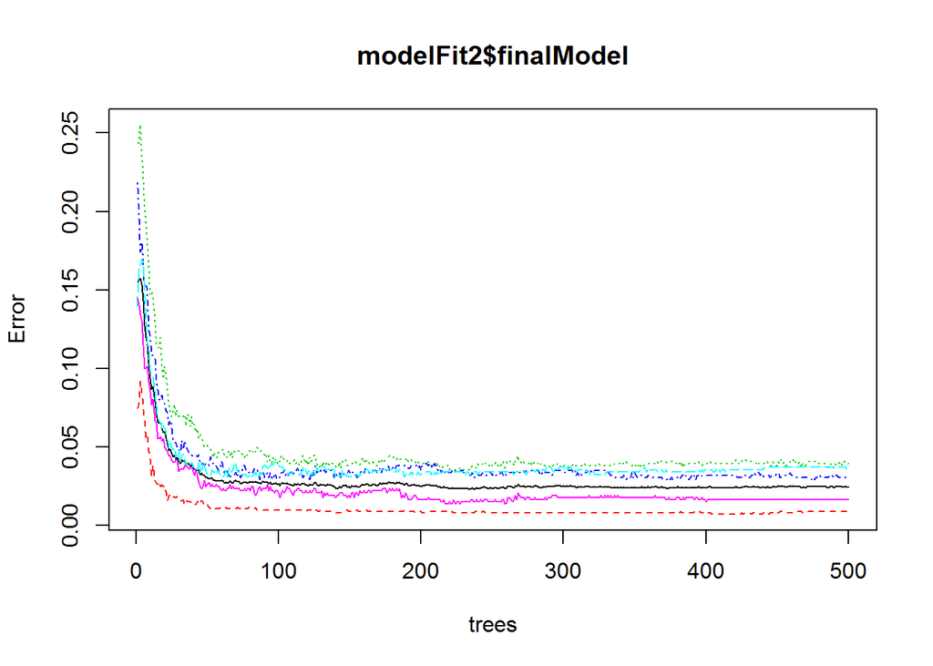

```r
plot(modelFit2$finalModel)
```

```r
modelFit2
```

```
## Random Forest
##
## 3927 samples
##   52 predictor
##    5 classes: 'A', 'B', 'C', 'D', 'E'
##
## No pre-processing
## Resampling: Cross-Validated (10 fold)
##
## Summary of sample sizes: 3534, 3533, 3535, 3534, 3534, 3534, ...
##
## Resampling results across tuning parameters:
##
##   mtry  Accuracy   Kappa      Accuracy SD  Kappa SD
##    2    0.9696836  0.9616371  0.013047114  0.01652506
##   27    0.9745299  0.9677755  0.008843945  0.01119421
##   52    0.9658753  0.9568265  0.011150300  0.01409622
##
## Accuracy was used to select the optimal model using  the largest value.
## The final value used for the model was mtry = 27.
```

```r
modelFit2$finalModel
```

```
##
## Call:
##  randomForest(x = x, y = y, mtry = param$mtry)
##                Type of random forest: classification
##                      Number of trees: 500
## No. of variables tried at each split: 27
##
##         OOB estimate of  error rate: 2.44%
## Confusion matrix:
##      A   B   C   D   E class.error
## A 1106   7   1   2   0 0.008960573
## B   21 730   8   1   0 0.039473684
## C    0  14 664   7   0 0.030656934
## D    2   0  18 621   3 0.035714286
## E    0   3   5   4 710 0.016620499
```

```r
predTest<-predict(modelFit2,newdata=testing)
confusionMatrix(predTest,testing$classe)
```

```
## Confusion Matrix and Statistics
##
##           Reference
## Prediction   A   B   C   D   E
##          A 277   5   1   2   1
##          B   1 181   4   0   0
##          C   0   3 161   1   1
##          D   0   0   5 157   1
##          E   1   0   0   0 177
##
## Overall Statistics
##
##                Accuracy : 0.9734
##                  95% CI : (0.9613, 0.9826)
##     No Information Rate : 0.285
##     P-Value [Acc > NIR] : < 2.2e-16
##
##                   Kappa : 0.9664
##  Mcnemar's Test P-Value : NA
##
## Statistics by Class:
##
##                      Class: A Class: B Class: C Class: D Class: E
## Sensitivity            0.9928   0.9577   0.9415   0.9812   0.9833
## Specificity            0.9871   0.9937   0.9938   0.9927   0.9987
## Pos Pred Value         0.9685   0.9731   0.9699   0.9632   0.9944
## Neg Pred Value         0.9971   0.9899   0.9877   0.9963   0.9963
## Prevalence             0.2850   0.1931   0.1747   0.1634   0.1839
## Detection Rate         0.2829   0.1849   0.1645   0.1604   0.1808
## Detection Prevalence   0.2921   0.1900   0.1696   0.1665   0.1818
## Balanced Accuracy      0.9900   0.9757   0.9677   0.9870   0.9910
```

```r
varImp(modelFit2)
```

```
## rf variable importance
##
##   only 20 most important variables shown (out of 52)
##
##                      Overall
## roll_belt             100.00
## pitch_forearm          62.18
## yaw_belt               56.81
## magnet_dumbbell_z      45.87
## pitch_belt             44.36
## magnet_dumbbell_y      43.02
## roll_forearm           36.24
## roll_dumbbell          23.83
## accel_forearm_x        19.56
## accel_dumbbell_y       19.37
## magnet_dumbbell_x      18.13
## magnet_belt_z          16.69
## magnet_belt_y          14.77
## accel_dumbbell_z       14.75
## accel_belt_z           14.60
## total_accel_dumbbell   12.50
## magnet_forearm_z       11.56
## gyros_belt_z           10.80
## magnet_belt_x          10.68
## yaw_dumbbell           10.46
```

The code below was provided from the project assignment for creating an answer set for submission of test case results. The modelFit2 was used to make the class predictions that were submitted. The results showed that this model predicted the correct class for each of the 20 test cases in the testSet (from pml-testing file) provided.

```r
pml_write_files = function(x){
    n=length(x)
    for(i in 1:n){
        filename=paste0("problem_id",i,"txt")
        write.table(x[i],file=filename,quote=FALSE,row.names=FALSE,col.names=FALSE)
    }
}

answers<-predict(modelFit2,newdata=testSet)

pml_write_files(answers)
```

### Conclusion

The results of this analysis support the idea that measured activity data can be modeled and classified. In our efforts to reproduce the classification results that were obtained in the original study, we have seen that it is possible to model the data and to predict the performance classification with a high degree of accuracy.